# ggplot2の辞書

やわらかクジラ

2021/02/11

# はじめに

## 辞書の説明

### 概要

- データの可視化と細かい部分の微調整をするための備忘録
- 気になる用語や関数について`ctrl + F`で検索
- グラフ全般にかかわる共通の書式は散布図のところに多く記述
  - 散布図(1)：タイトルと軸、散布図(2)：凡例の調整など

### 参考情報

- [公式のレファレンス](https://ggplot2.tidyverse.org/reference/index.html)
  - 各関数と引数の意味がグラフ付きで解説されている
- [ggplot2: Elegant Graphics for Data Analysis](https://ggplot2-book.org/)
  - by Hadley Wickham
- [R Graphics Cookbook, 2nd edition](https://r-graphics.org/)
  - by Winston Chang

### chunkの全体設定

- `fig.width`と`fig.height`でhtml上での図の大きさ一括指定
  - デフォルトは7

```r
# 全体
knitr::opts_chunk$set(echo = TRUE, warning = FALSE, message = FALSE,
                      fig.width = 5, fig.height = 4)
```

# 1 散布図(1): 2変数のみ

## 1.1 デフォルトの図

- R for Data Scienceにならって、mpgデータを使用
  - https://r4ds.had.co.nz/data-visualisation.html#first-steps
- mpgデータ
  - 車の人気モデル38種類における燃料効率データ（1999-2008年）
- 使用変数の説明
  - `displ`: エンジンの排気量（リットル）
  - `hwy`: 燃料効率（miles per gallon[mpg]）

```r
library(tidyverse)
```

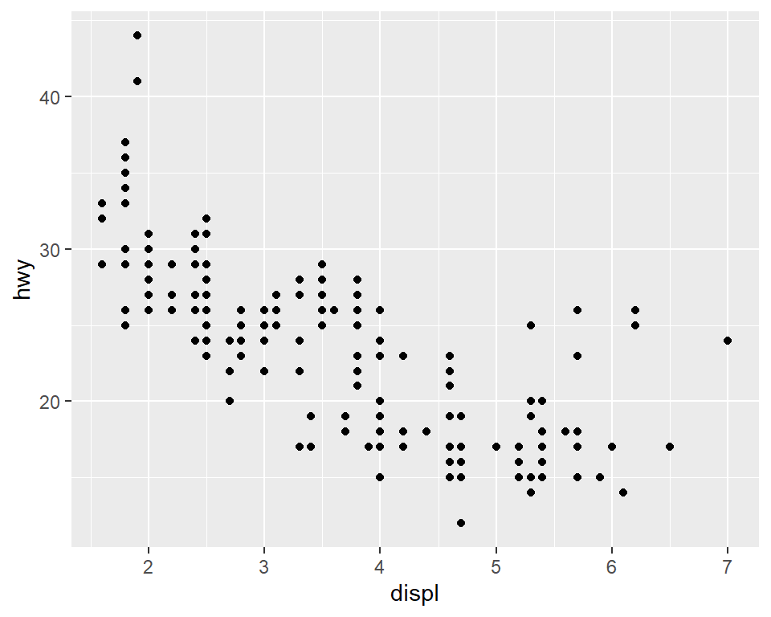

```r
p <-
ggplot(mpg, aes(x = displ, y = hwy))

p + geom_point()
```

## 1.2 点の書式

### 1.2.1 色

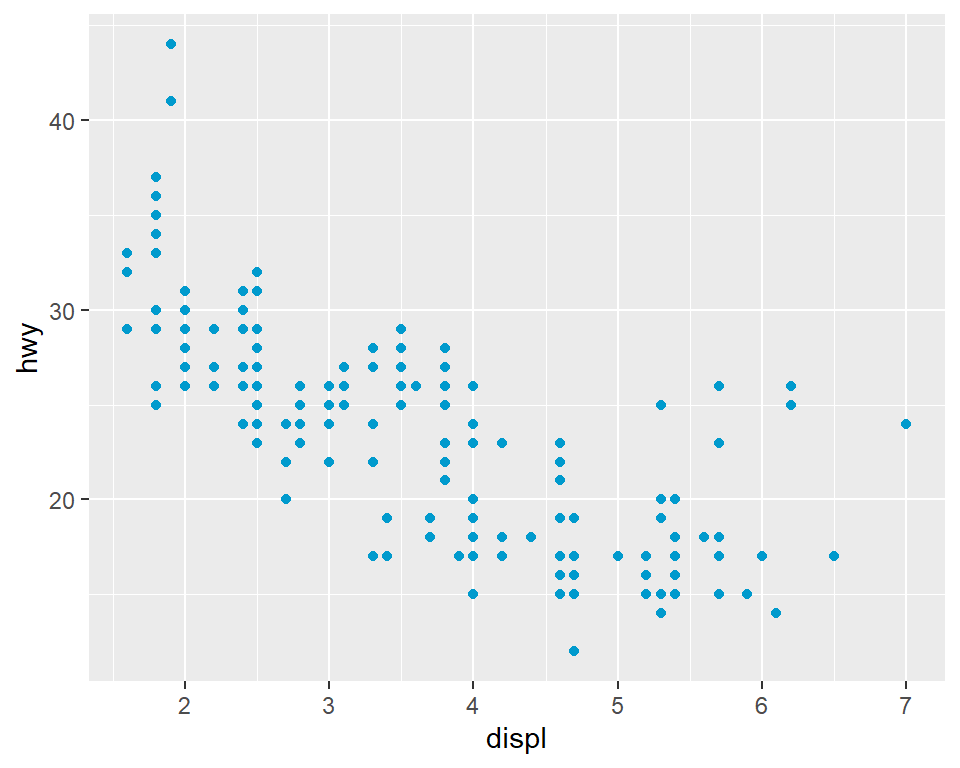

```r
p +
  geom_point(color = "deepskyblue3")
```

### 1.2.2 大きさ

#### 1.5

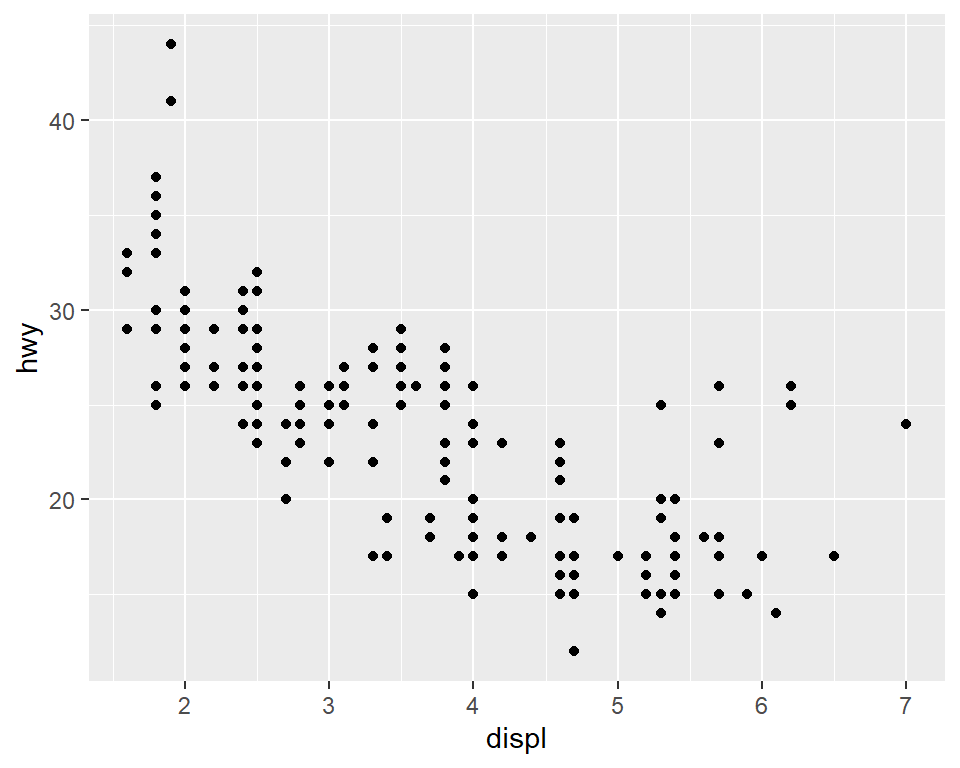

```r
p +
  geom_point(size = 1.5)
```

#### 3

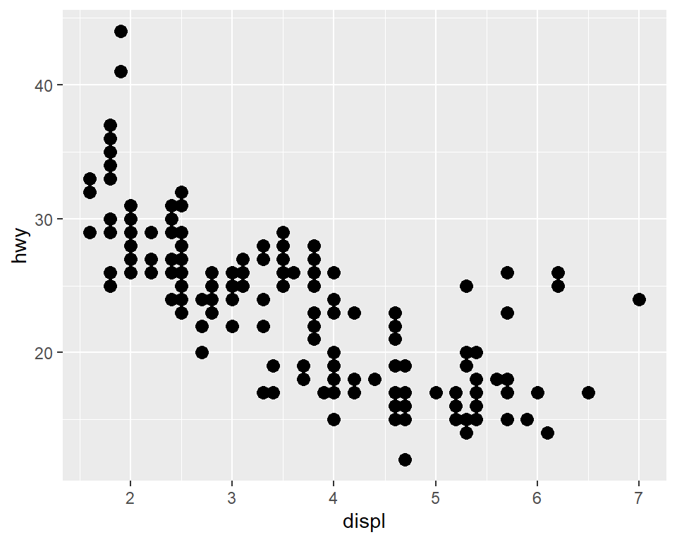

```r
p +
  geom_point(size = 3)
```

#### 5

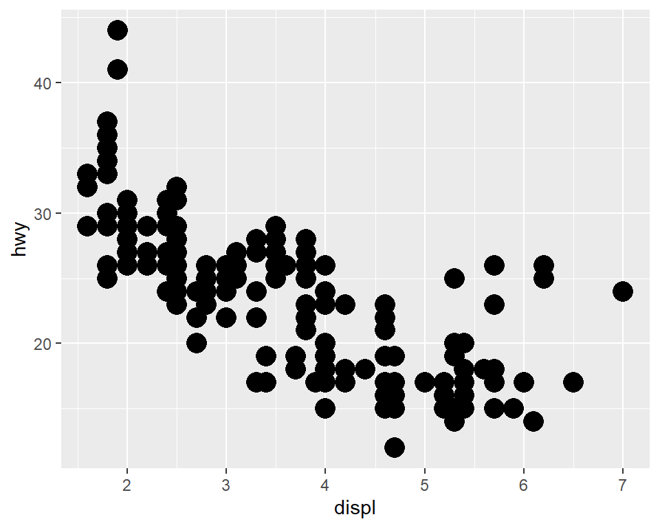

```r
p +
  geom_point(size = 5)
```

### 1.2.3 濃さ（透明度）

#### 0.1

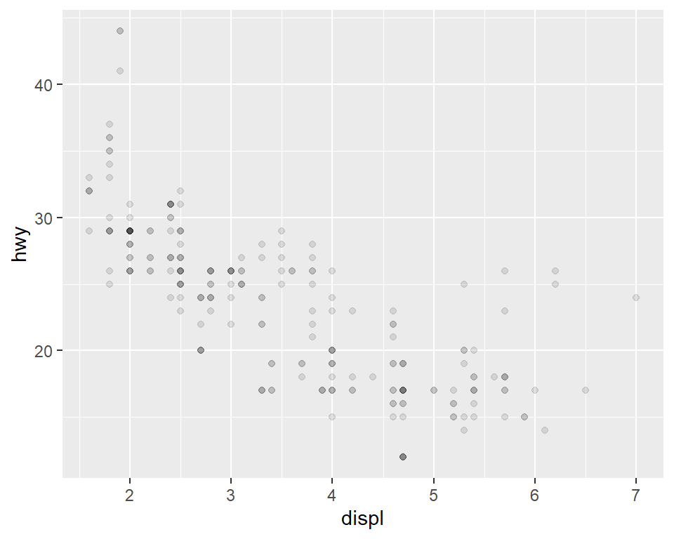

```r
p +
  geom_point(alpha = 0.1)
```

#### 0.5

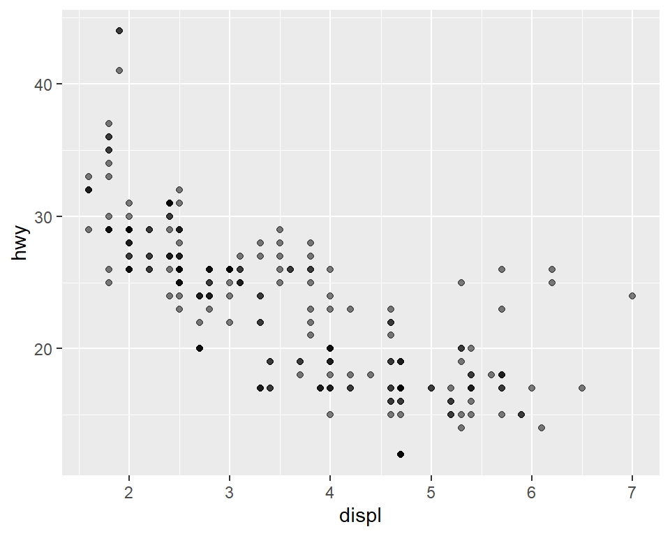

```r
p +
  geom_point(alpha = 0.5)
```

#### 0.7

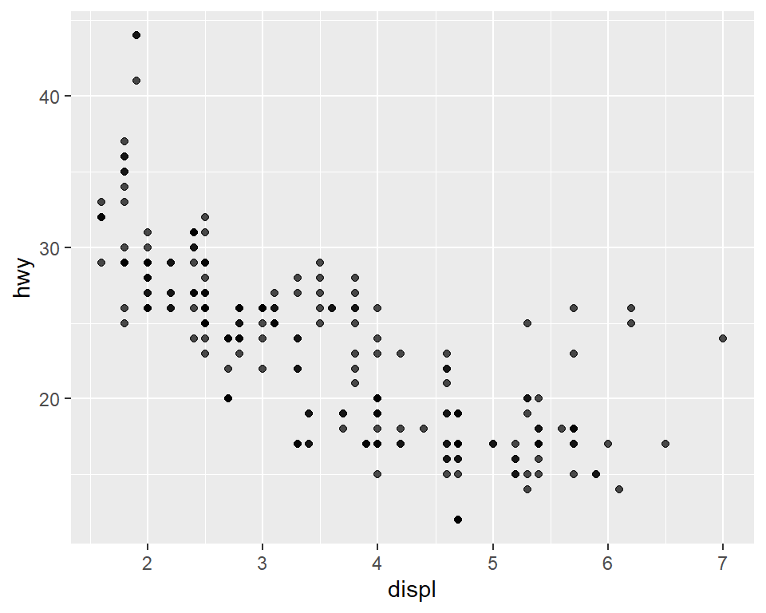

```r
p +
  geom_point(alpha = 0.7)
```

### 1.2.4 形

- 他の形は`vignette("ggplot2-specs")`のshapeを参考
- 例
  - ■：“square”
  - ♦：“diamond”
  - △：“triangle open”
  - ×：“cross”

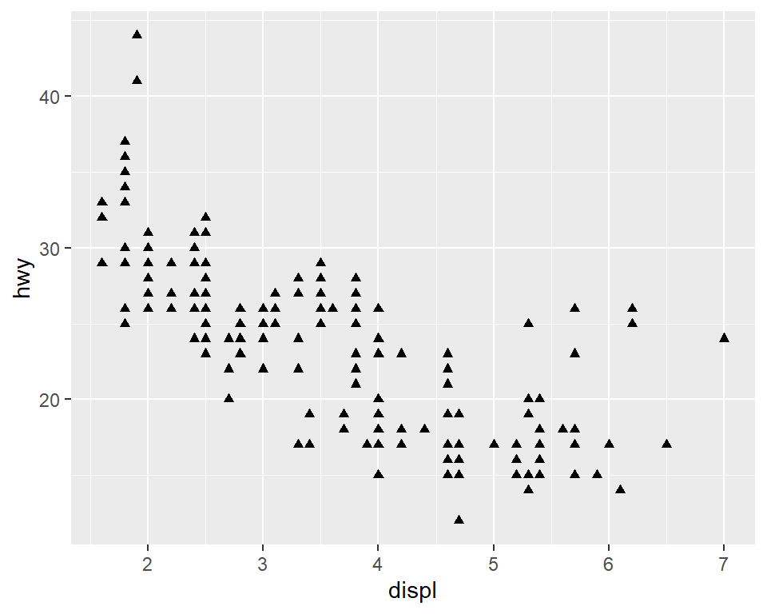

```r
p +
  geom_point(shape = "triangle")
```

### 1.2.5 画像

[figure not shown]

```r
library(ggimage)

p +
  geom_image(aes(image = "image/kujira.PNG"))
```

## 1.3 タイトルと軸: labs()

### 1.3.1 タイトル

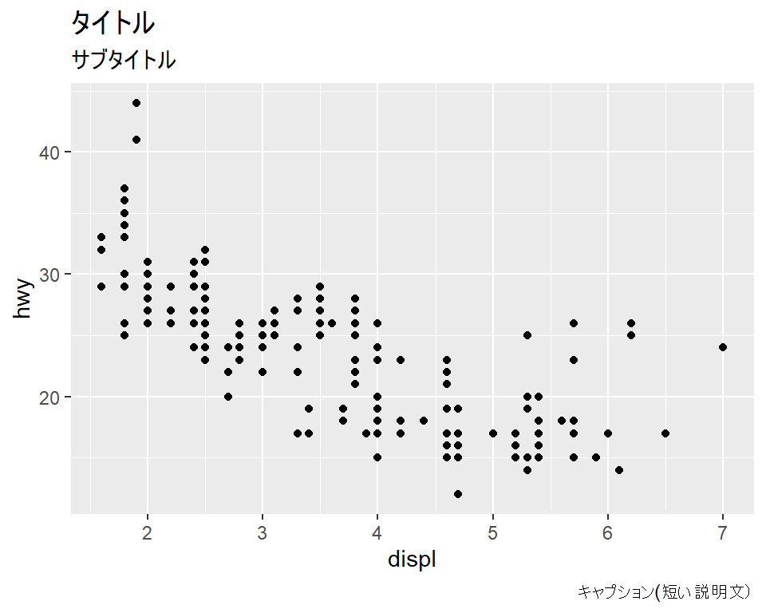

```r
p +
  geom_point() +
  labs(
    title = "タイトル",
    subtitle = "サブタイトル",
    caption = "キャプション(短い説明文）"
       )
```

#### 文字サイズ変更

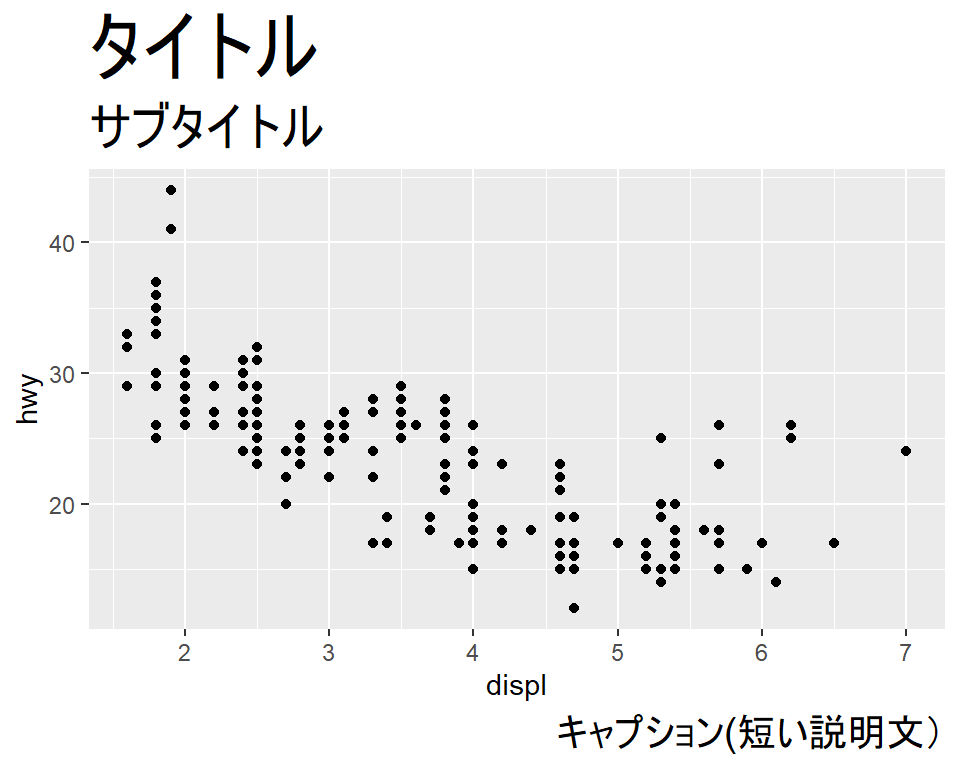

```r
p +
  geom_point() +
  labs(
    title = "タイトル",
    subtitle = "サブタイトル",
    caption = "キャプション(短い説明文）"
       ) +
  theme(
    plot.title    = element_text(size = 30),
    plot.subtitle = element_text(size = 20),
    plot.caption  = element_text(size = 15)
  )
```

#### 太字にして色を変更

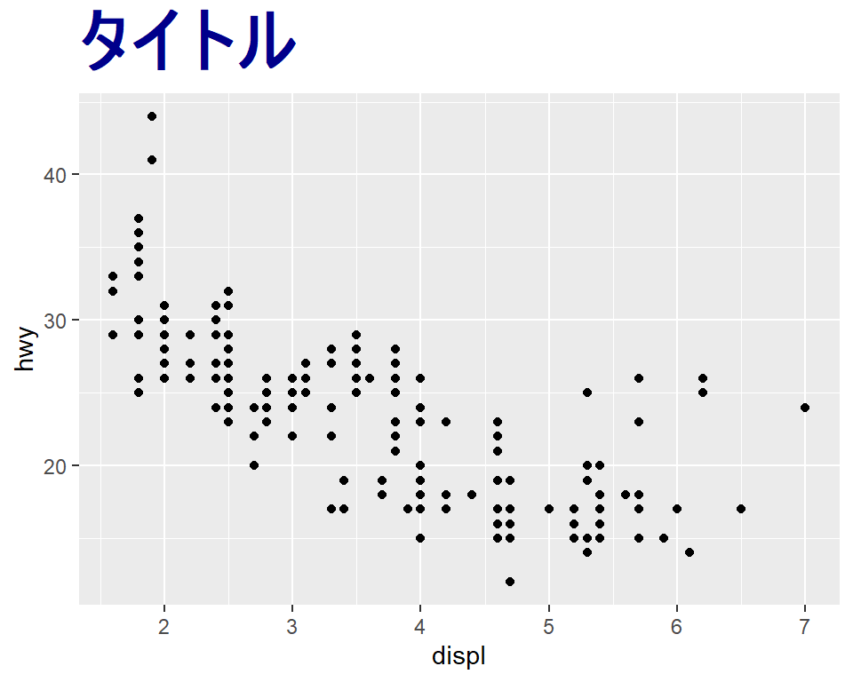

```r
p +
  geom_point() +
  labs(
    title = "タイトル") +
  theme(
    plot.title    = element_text(size = 30,
                                 face = "bold",      # 太字
                                 color = "darkblue") # 色
  )
```

#### 位置変更

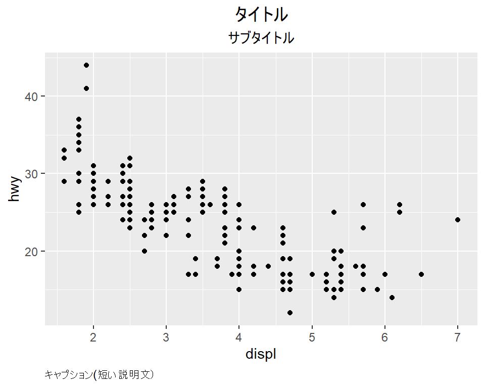

```r
p +
  geom_point() +
  labs(
    title = "タイトル",
    subtitle = "サブタイトル",
    caption = "キャプション(短い説明文）"
       ) +
  theme(
    plot.title    = element_text(hjust = 0.5),   # 水平方向0-1の範囲で相対的な位置を指定
    plot.subtitle    = element_text(hjust = 0.5),
    plot.caption  = element_text(hjust = 0)
  )
```

### 1.3.2 フォント(タイトル)

- 以下はwindowsでのやり方を想定

#### MS明朝

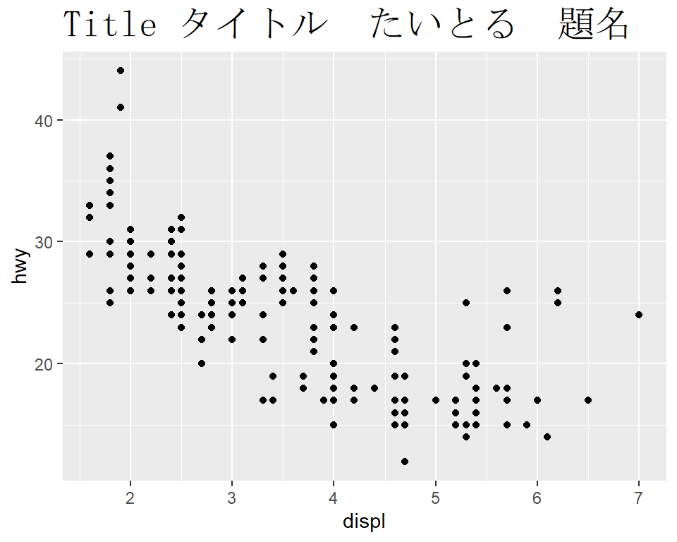

```r
windowsFonts("mincho" = windowsFont("MS Mincho"))

p +
  geom_point() +
  labs(title = "Title タイトル　たいとる　題名") +
  theme(plot.title = element_text(family = "mincho",
                                  size = 20))
```

#### メイリオ

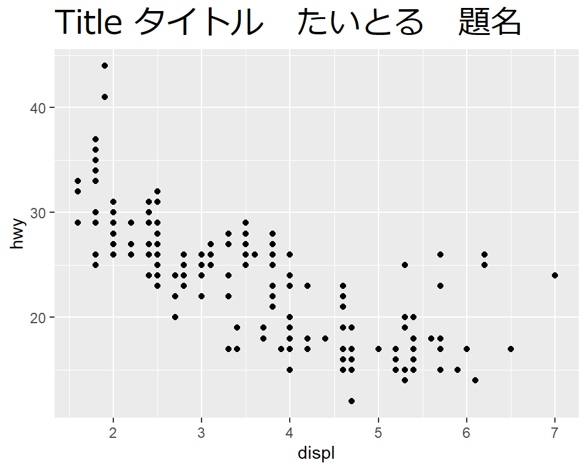

```r
windowsFonts("MEI" = windowsFont("Meiryo"))

p +
  geom_point() +
  labs(title = "Title タイトル　たいとる　題名") +
  theme(plot.title = element_text(family = "MEI",
                                  size = 20))
```

#### Times New Roman

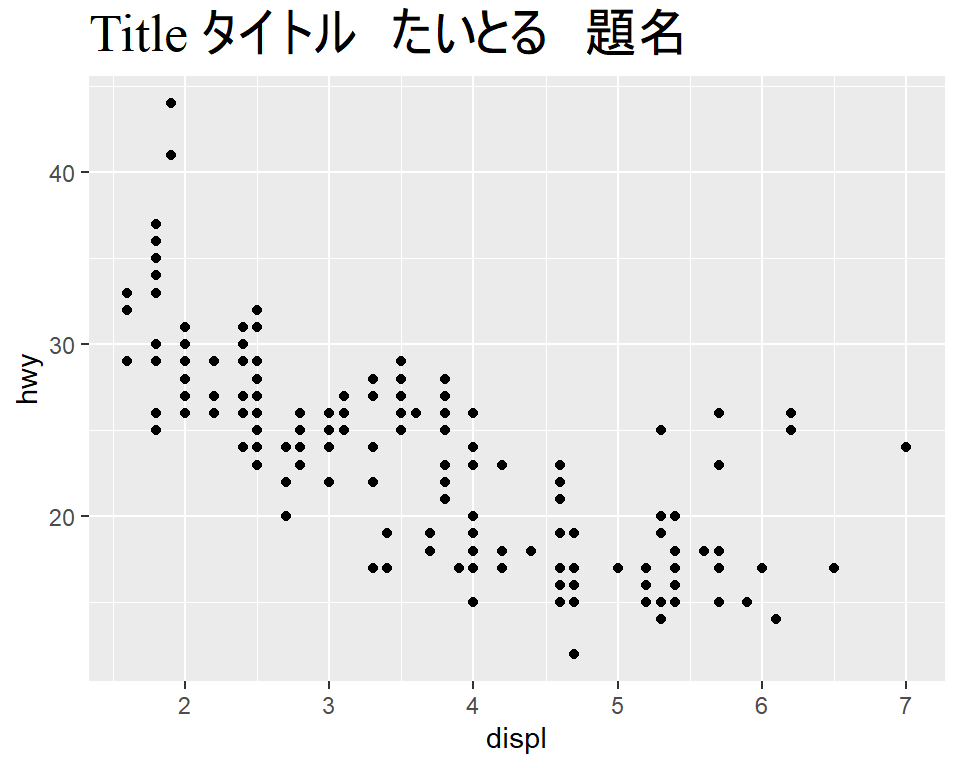

```r
p +
  geom_point() +
  labs(title = "Title タイトル　たいとる　題名") +
  theme(plot.title = element_text(family = "serif",
                                  size = 20))
```

#### Arial

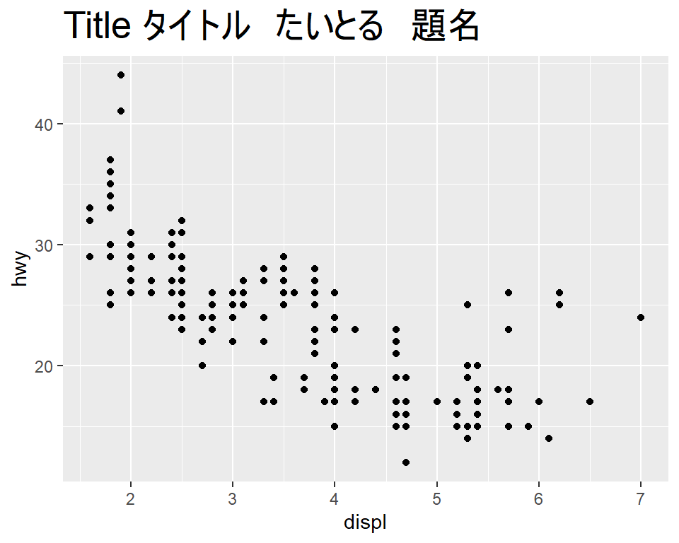

```r
p +
  geom_point() +
  labs(title = "Title タイトル　たいとる　題名") +
  theme(plot.title = element_text(family = "sans",
                                  size = 20))
```

#### Courier New

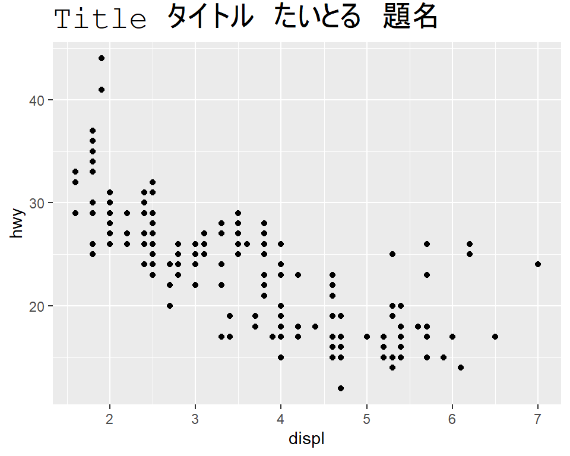

```r
p +
  geom_point() +
  labs(title = "Title タイトル　たいとる　題名") +
  theme(plot.title = element_text(family = "mono",
                                  size = 20))
```

### 1.3.3 軸の名前

- 名前を消したいときは `x = ""`のようにしてもできる

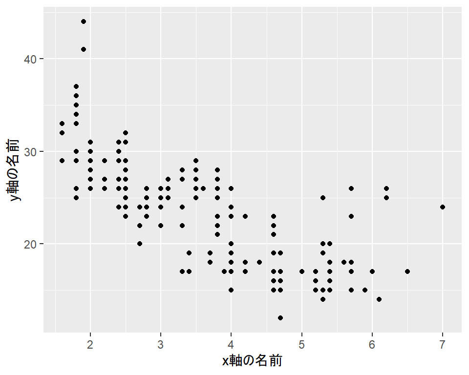

```r
p +
  geom_point() +
  labs(
    x = "x軸の名前",
    y = "y軸の名前"
       )
```

### 1.3.4 フォント(軸)

#### 1.3.4.1 数値

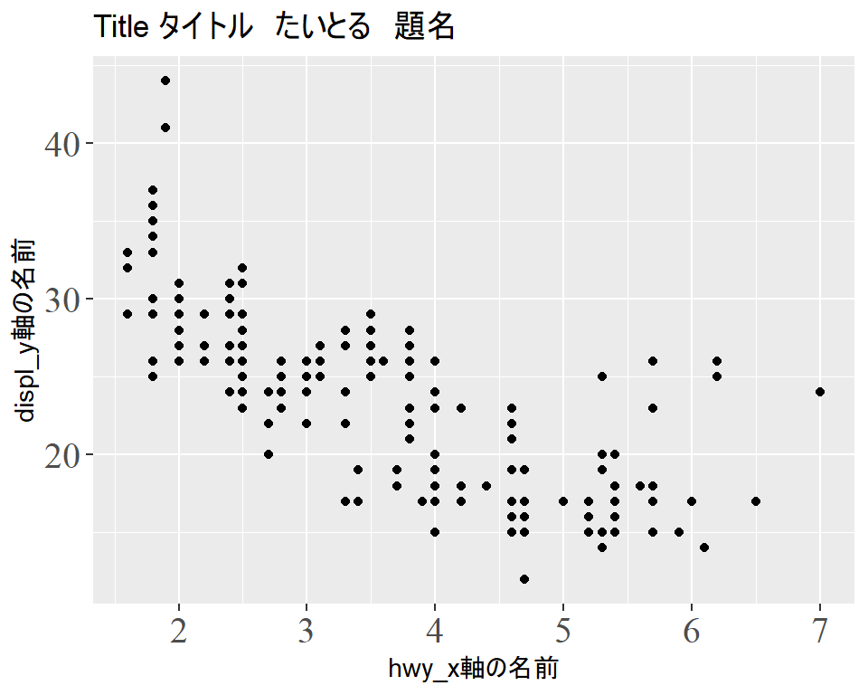

```r
p +
  geom_point() +
  labs(
    title = "Title タイトル　たいとる　題名",
    x = "hwy_x軸の名前",
    y = "displ_y軸の名前"
       ) +
  theme(axis.text =  element_text(family = "serif",
                                  size = 15))
```

#### 1.3.4.2 タイトル（軸の名前）

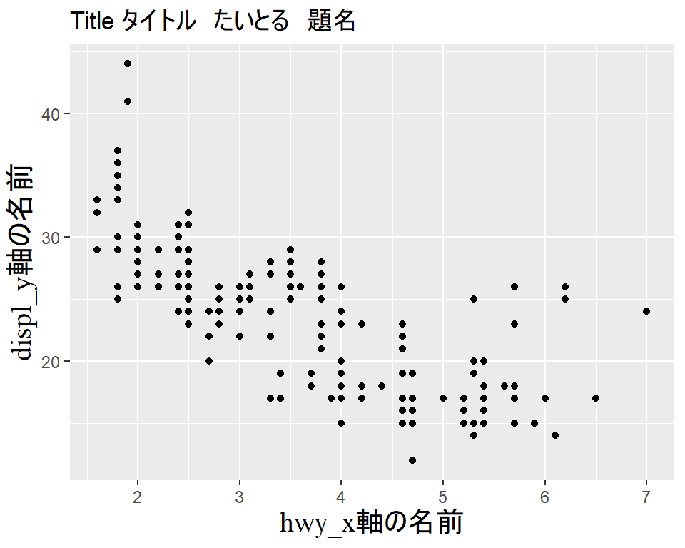

```r
p +
  geom_point() +
  labs(
    title = "Title タイトル　たいとる　題名",
    x = "hwy_x軸の名前",
    y = "displ_y軸の名前"
       ) +
  theme(axis.title =  element_text(family = "serif",
                                   size = 15))
```

### 1.3.5 フォント(一括)

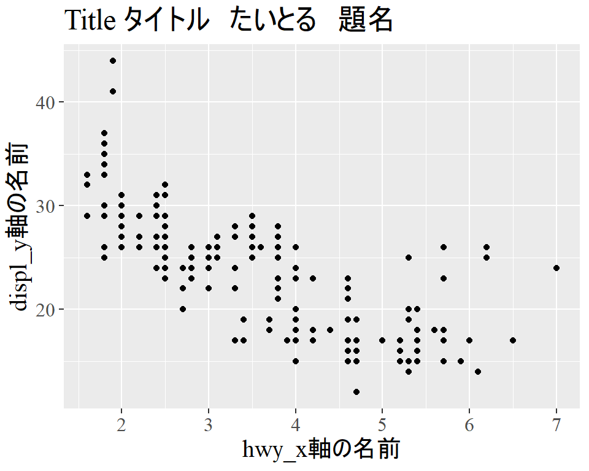

```r
p +
  geom_point() +
  labs(
    title = "Title タイトル　たいとる　題名",
    x = "hwy_x軸の名前",
    y = "displ_y軸の名前"
       ) +
  theme(text =  element_text(family = "serif",
                                  size = 15))
```

### 1.3.6 軸の数値範囲: scale_continuous()

#### 1.3.6.1 数値範囲確認

```r
mpg %>%
  select(displ, hwy) %>% # displとhwyを選んでsummary()に渡す
  summary()
```

```
##      displ            hwy
##  Min.   :1.600   Min.   :12.00
##  1st Qu.:2.400   1st Qu.:18.00
##  Median :3.300   Median :24.00
##  Mean   :3.472   Mean   :23.44
##  3rd Qu.:4.600   3rd Qu.:27.00
##  Max.   :7.000   Max.   :44.00
```

#### 1.3.6.2 範囲を指定して１ずつ増やす

- 数値型の場合は、`scale_x_continuous()`および`scale_y_continuous()`のbreaksで指定
- 表示範囲を強制指定する場合は`limits =`

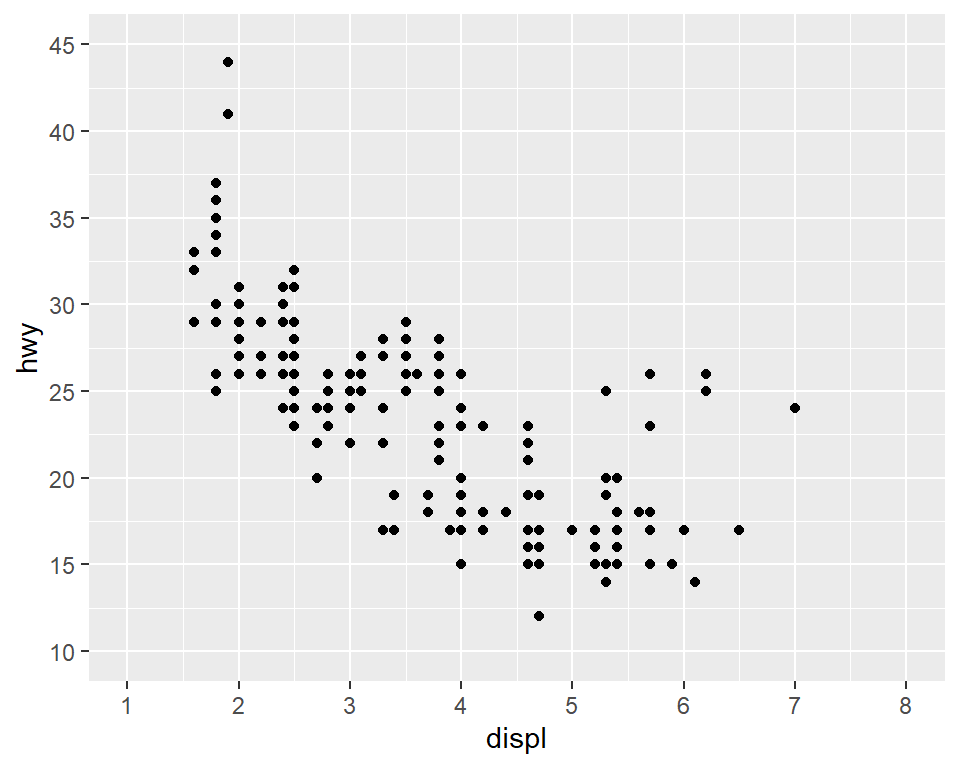

```r
p +
  geom_point() +
  scale_x_continuous(
    breaks = seq(from = 1, to = 8, by = 1), # 1から8まで1ずつ増える
    limits = c(1, 8)) +                     # 1を表示したい場合
  scale_y_continuous(
    breaks = seq(from = 10, to = 45, by = 5), # 10から45まで5ずつ増える
    limits = c(10, 45))
```

##### 1.3.6.2.1 手動で指定

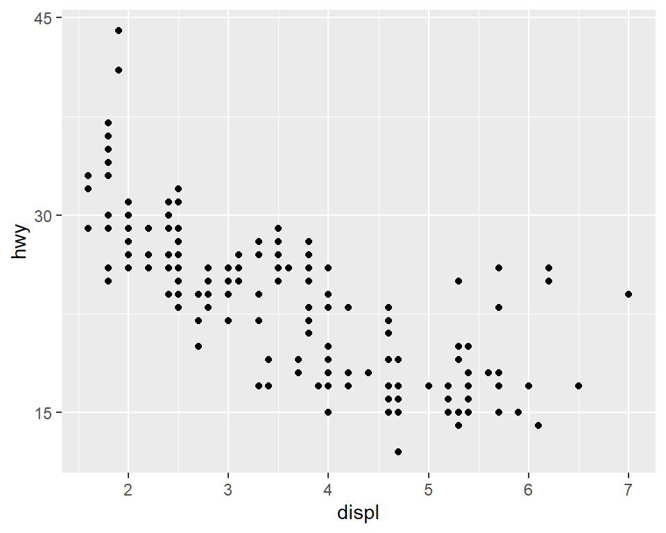

```r
p +
  geom_point() +
  scale_y_continuous(
    breaks = c(15, 30, 45))
```

### 1.3.7 軸の数値のサイズ

#### 9

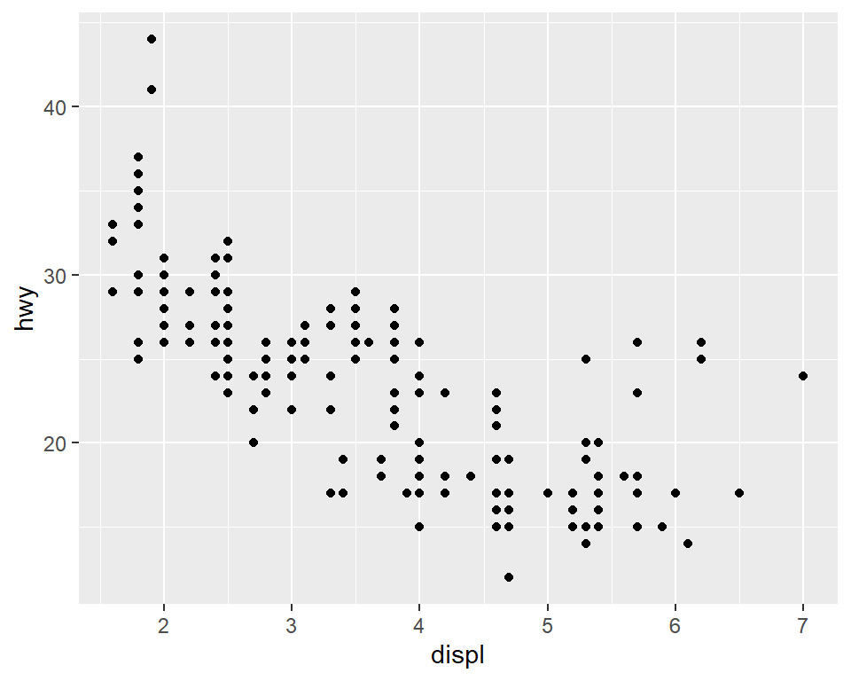

```r
p +
  geom_point() +
  theme(axis.text = element_text(size = 9)) # 単位はpt
```

#### 12

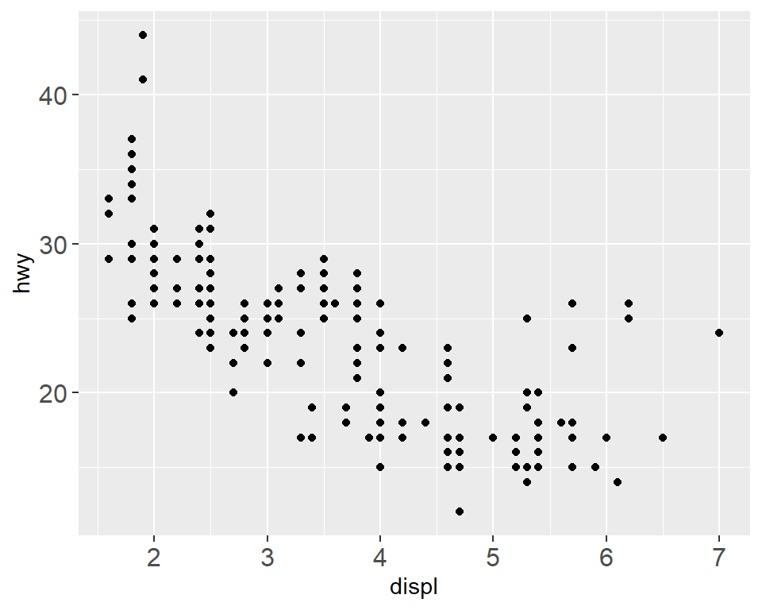

```r
p +
  geom_point() +
  theme(axis.text = element_text(size = 12)) # 単位はpt
```

#### 16

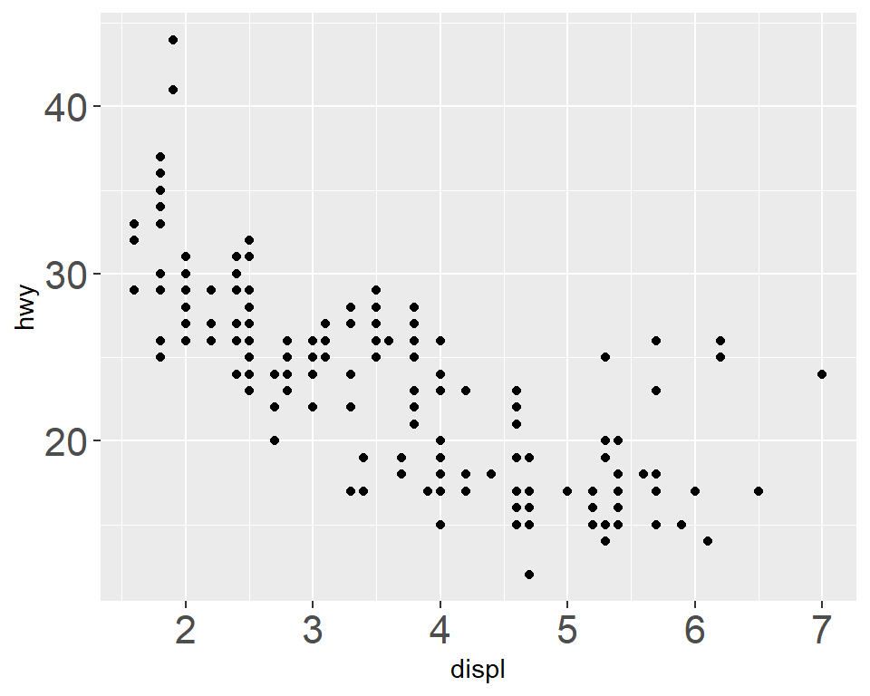

```r
p +
  geom_point() +
  theme(axis.text = element_text(size = 16)) # 単位はpt
```

## 1.4 グラフ中に線やテキストを追加

### 1.4.1 横線: geom_hline()

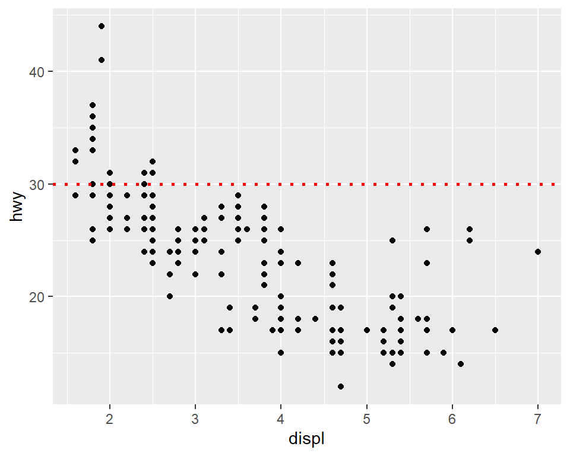

```r
p +
  geom_point() +
  geom_hline(yintercept = 30,     # 座標の位置
             linetype = "dotted", # 点線
             color = "red",       # 色
             size = 1)            # 大きさ
```

### 1.4.2 縦線:geom_vline()

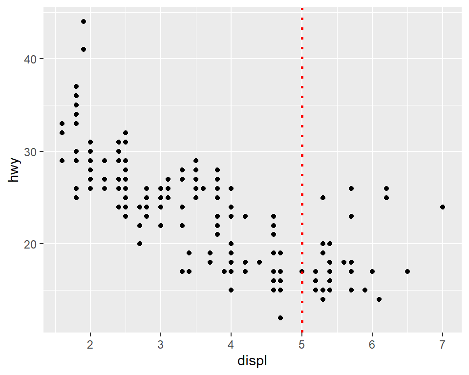

```r
p +
  geom_point() +
  geom_vline(xintercept = 5,
             linetype = "dotted",
             color = "red",
             size = 1)
```

### 1.4.3 テキスト: annotate()

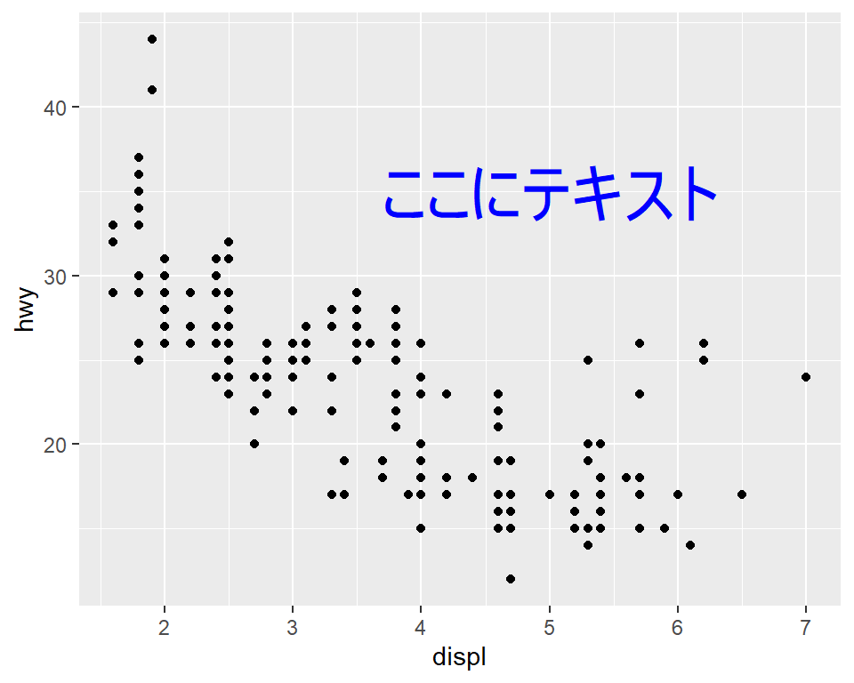

```r
p +
  geom_point() +
  annotate(geom = "text",
           x = 5, y = 35,  # テキストの中心座標位置
           label = "ここにテキスト",
           color = "blue",
           size = 10)
```

#### 1.4.3.1 角度

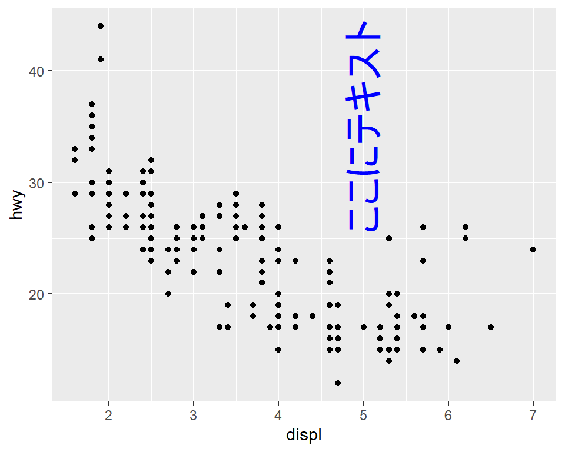

```r
p +
  geom_point() +
  annotate(geom = "text",
           x = 5, y = 35,  # テキストの中心座標位置
           label = "ここにテキスト",
           color = "blue",
           size = 9,
           angle = 90)
```